# Broken Effects or ‘Fixed’ Effects?

Recitation Period 8

Alexander Dean

Vanderbilt University

2025-03-04

# Introductory Spiel

## What We Will Cover Today

1. The basic intuition of two way fixed effects (TWFE)
2. When TWFE is most commonly used
3. When a TWFE estimator is biased and inconsistent
4. Some alternative estiamtors/statistical options for use when TWFE is biased/inconsistent

## What is TWFE?

$Y_{it} = \alpha_{i} + \gamma_{t} + \beta D_{it} + \textbf{X}^{'}_{it} + \epsilon_{it}$,

where:

- $Y_{it} =$ outcome *Y* for unit *i* in period *t*
- $\alpha_{i} =$ unit-fixed effects
- $\gamma_{t} =$ time=fixed effects
- $D_{it} =$ a binary treatment assignment variable for unit *i* in period *t*
- $\textbf{X}^{'}_{it} =$ a matrix of covariates for unit *i* in period *t*
- $\epsilon_{it}=$ is the error term with mean zero

## Why TWFE?

- Allows for controlling of time-invariant heterogeneity across units $(\alpha_{i})$ like differences in population size
- Allows for controlling time-varying trends or shocks that affects all units at the same time $(\lambda_{t})$ like an economic shock
- Can recover the ATE under standard assumptions with panel data

# But what are the standard TWFE assumptions?

## (1) Strict Exogeneity of Treatment

- $\mathbb{E}[\epsilon_{it}|\mathbb{X}_{it}, \alpha_{i}, \gamma_{t}]$
- No selection into treatment based off of unobserved time-varying factors which also affect the outcome

## (2) No Anticipation

- $\mathbb{E}[Y_{it} | D_{it+s} = 1, X_{it}, \alpha_i, \lambda_t] = \mathbb{E}[Y_{it} | D_{it+s} = 0, X_{it}, \alpha_i, \lambda_t] \quad \forall \quad s > 0$
- Units don’t change behavior in anticipation of receiving treatment

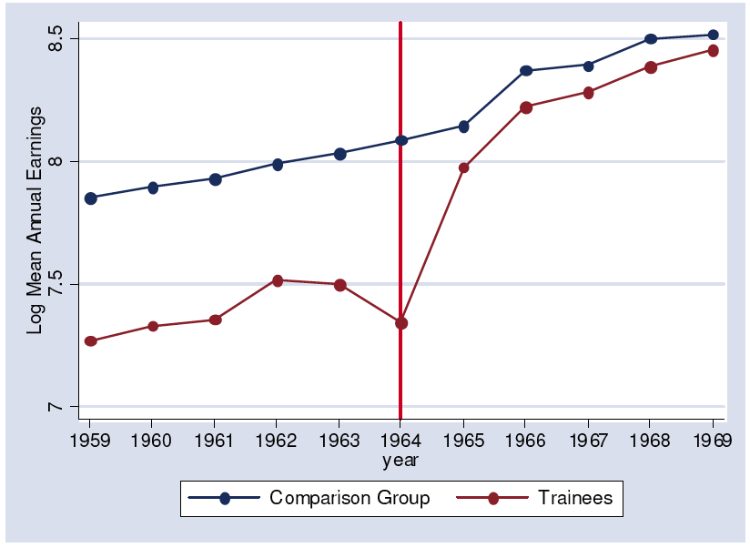

Ashenfelter’s Dip

## (3) Parallel Trends

- $\mathbb{E}[Y_{it}(0) - Y_{it-1}(0) | D_{it} = 1] = \mathbb{E}[Y_{it}(0) - Y_{it-1}(0) | D_{it} = 0]$
- Absent being assigned treatment, units would have the same outcome trends over time
- Related to no anticipation
- Allows for valid creation of the counterfactual under no treatment

## (4) Homogenous Treatment

- $\mathbb{E}[Y_{it}(1) - Y_{it}(0) | D_{it} = 1] = \mathbb{E}[Y_{i^{\prime}t^{\prime}}(1) - Y_{i^{\prime}t^{\prime}}(0) | D_{i^{\prime}t^{\prime}} = 1]$
- Treatment must be homogenous over unit and time (very important)
- We will come back to this later

## (5) Monotonacity in Unit Assignment

- $D_{it} \geq D_{it-1}$
- No treatment reversal
- Incompotatible with staggered treatment assignments

## What if my data violates one of the TWFE Assumptions?

1. Your TWFE estimator will be (i) biased and/or (ii) inconsistent (Goodmanbacon 2021; de Chaisemartin & D’haultfœuille 2020; Gibbons et al. 2023)
2. Luckily, there have been many advances in finding consistent and unbiased estimators for panel data with heterogenous treatment, staggered treatment, violation of parallel trends, etc.!

# So why can TWFE be biased?

## Gibbons et al. 2023 Proposition 1

- We are going to solve the proof on the board
- This will show *why* TWFE can be biased under heterogeneous treatment assignment

# What Now?

## Alternative Estimators:

- There has been an outpouring of alternative estimators that relax the TWFE assumptions, allowing you to recover the ATT or the ATE!
1. Callaway & Sant’Anna 2021
2. de Chaisemartin & d’Haultfœuille 2020
3. de Chaisemartin & d’Haultfœuille 2023
4. Imai et al. 2023
5. Sun & Abraham 2021
6. Arkhangelsky et al. (2021)
7. Others!

Alexander Dean (Vanderbilt University)